# Parkinson’s disease UPDRS analysis with LASSO Regression

Hieu Nguyen

In this notebook, we are going to work with a Parkinsons Disease dataset, which contains information on 42 patients with Parkinson’s disease. The outcome of interest is UPDRS, which is the total unified Parkinson’s disease rating scale. The first 96 features, X1–X96, have been derived from audio recordings of speech tests while feature X97 is already known to be informative for UPDRS.

We calculate the estimated coefficients to give a measure of the relative importance of the features in the fitted model.The dataset will be split into a training set with 30 patients and a test set with 12 patients

```r
parData = read.csv("parkinsons.csv",header=TRUE)
X = model.matrix(UPDRS ~., parData)[,-1]
X = scale(X)[,-1]
y = parData$UPDRS
trainIdx = sample(1:nrow(X), 30)
testIdx = -trainIdx
```

#### First we attempt to fit our training data to the linear regression model, as the baseline, and we get the result as follow

```r
options(width = 100)
lm(y[trainIdx] ~ X[trainIdx,])
```

```
Call:
lm(formula = y[trainIdx] ~ X[trainIdx, ])

Coefficients:
     (Intercept)   X[trainIdx, ]X1   X[trainIdx, ]X2   X[trainIdx, ]X3   X[trainIdx, ]X4
           31.83            476.60           -326.60            197.89           -137.53
 X[trainIdx, ]X5   X[trainIdx, ]X6   X[trainIdx, ]X7   X[trainIdx, ]X8   X[trainIdx, ]X9
         -207.08             88.66           -221.77            113.97            -26.60
X[trainIdx, ]X10  X[trainIdx, ]X11  X[trainIdx, ]X12  X[trainIdx, ]X13  X[trainIdx, ]X14
           67.71            267.11           -172.48          20780.23           9892.77
X[trainIdx, ]X15  X[trainIdx, ]X16  X[trainIdx, ]X17  X[trainIdx, ]X18  X[trainIdx, ]X19
         1634.98          23162.23          17676.58             24.62           -181.97
X[trainIdx, ]X20  X[trainIdx, ]X21  X[trainIdx, ]X22  X[trainIdx, ]X23  X[trainIdx, ]X24
           35.74             76.89           -106.79           -172.66            120.44
X[trainIdx, ]X25  X[trainIdx, ]X26  X[trainIdx, ]X27  X[trainIdx, ]X28  X[trainIdx, ]X29
       -20758.21          -9796.42          -1817.06         -23003.52         -17683.71
X[trainIdx, ]X30  X[trainIdx, ]X31  X[trainIdx, ]X32  X[trainIdx, ]X33  X[trainIdx, ]X34
              NA                NA                NA                NA                NA
X[trainIdx, ]X35  X[trainIdx, ]X36  X[trainIdx, ]X37  X[trainIdx, ]X38  X[trainIdx, ]X39
              NA                NA                NA                NA                NA
X[trainIdx, ]X40  X[trainIdx, ]X41  X[trainIdx, ]X42  X[trainIdx, ]X43  X[trainIdx, ]X44
              NA                NA                NA                NA                NA
X[trainIdx, ]X45  X[trainIdx, ]X46  X[trainIdx, ]X47  X[trainIdx, ]X48  X[trainIdx, ]X49
              NA                NA                NA                NA                NA
X[trainIdx, ]X50  X[trainIdx, ]X51  X[trainIdx, ]X52  X[trainIdx, ]X53  X[trainIdx, ]X54
              NA                NA                NA                NA                NA
X[trainIdx, ]X55  X[trainIdx, ]X56  X[trainIdx, ]X57  X[trainIdx, ]X58  X[trainIdx, ]X59
              NA                NA                NA                NA                NA
X[trainIdx, ]X60  X[trainIdx, ]X61  X[trainIdx, ]X62  X[trainIdx, ]X63  X[trainIdx, ]X64
              NA                NA                NA                NA                NA
X[trainIdx, ]X65  X[trainIdx, ]X66  X[trainIdx, ]X67  X[trainIdx, ]X68  X[trainIdx, ]X69
              NA                NA                NA                NA                NA
X[trainIdx, ]X70  X[trainIdx, ]X71  X[trainIdx, ]X72  X[trainIdx, ]X73  X[trainIdx, ]X74
              NA                NA                NA                NA                NA
X[trainIdx, ]X75  X[trainIdx, ]X76  X[trainIdx, ]X77  X[trainIdx, ]X78  X[trainIdx, ]X79
              NA                NA                NA                NA                NA
X[trainIdx, ]X80  X[trainIdx, ]X81  X[trainIdx, ]X82  X[trainIdx, ]X83  X[trainIdx, ]X84
              NA                NA                NA                NA                NA
X[trainIdx, ]X85  X[trainIdx, ]X86  X[trainIdx, ]X87  X[trainIdx, ]X88  X[trainIdx, ]X89
              NA                NA                NA                NA                NA
X[trainIdx, ]X90  X[trainIdx, ]X91  X[trainIdx, ]X92  X[trainIdx, ]X93  X[trainIdx, ]X94
              NA                NA                NA                NA                NA
X[trainIdx, ]X95  X[trainIdx, ]X96  X[trainIdx, ]X97
              NA                NA                NA
```

#### Now use the LASSO to fit the training data, using leave-one- out cross-validation to find the tuning parameter $\lambda$, which means nfolds=30. Besides, the to set grid = 10^seq(3,- 1,100) and thresh=1e-10.

First, we will train our LASSO model

```r
grid = 10^seq(3,-1,length = 100)
lassoModel = glmnet(X[trainIdx,],
                    y[trainIdx],
                    alpha=1,
                    lambda=grid,
                    thresh=1e-10)
```

Then we will find the optimal lambda via Cross validation on the training data.

```r
cvResult = cv.glmnet(X[trainIdx,],
                    y[trainIdx],
                    alpha=1,
                    lambda=grid,
                    nfolds=30,
                    thresh=1e-10,
                    grouped = F)
paste("The optimal lambda is",cvResult$lambda.min)
```

```
[1] "The optimal lambda is 0.932603346883219"
```

```r
bestLamd= cvResult$lambda.min
```

The Cross validation Error can be ploted against Log($\lambda$) as below.

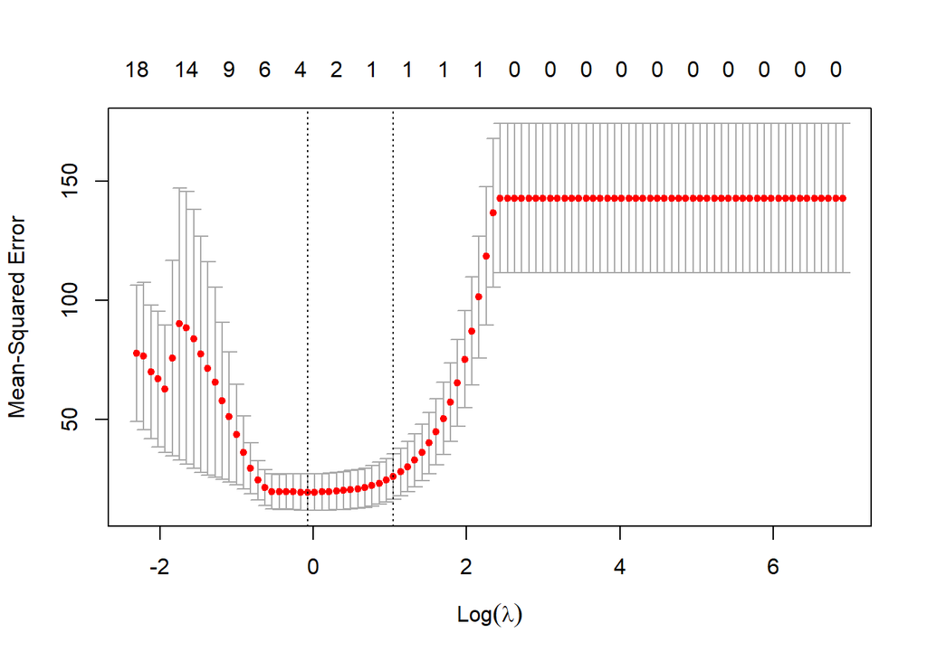

```r
plot(cvResult)
```

The test error then can be computed with the optimal $\lambda$ of 0.9326033

```r
lassoPred = predict(lassoModel, s=bestLamd, newx=X[testIdx,])
paste("The MSE is",mean((lassoPred - y[testIdx])^2))
```

```
[1] "The MSE is 5.91711611941864"
```

With the optimal $\lambda$, we are able to compute the coefficients of all features, and define what features are selected under this model (The features with coefficient reduced to 0 will not be shown)

```r
lassoCoef= predict(cvResult, type = "coefficients", s=bestLamd)
lasCoef = lassoCoef[lassoCoef[,1]!=0,]
lasCoef
```

```
(Intercept)         X95         X97
 26.3025760   0.4187074   9.1367477
```

So, our final model for the UPDRS is the model with $\lambda$ = 0.9326033:

UPDRS = 26.303 + 0.419 X95 + 9.137 X97

Lasso is a form of dimension reduction methods with variable selection, which aims to produces simpler and more interpretable models that involve only a subset of the predictors. In our case, only 2 features X95 and X97 are used. Our prediction now is based on 2 variables rather than 97 variables. However, in our dataset the response UPDRS is a function of 97 predictors and the Lasso could under fit with less than ideal number of predictors, especially when we only have 30 observation for training the model. This could lead to poor performance on unseen data.

#### If we do a different random split into training and test sets, and fit the LASSO model again as below

```r
seeds = c(538,239,275)
for (seed in seeds)
{
set.seed(seed,sample.kind="Rounding")
trainIdx1 = sample(1:nrow(X), 30)
testIdx1 = -trainIdx1

cvResult1 = cv.glmnet(X[trainIdx1,],
                    y[trainIdx1],
                    alpha=1,
                    lambda=grid,
                    nfolds=30,
                    thresh=1e-10,
                    grouped = F)

bestLamd1= cvResult1$lambda.min

lassoCoef1= predict(cvResult1, type = "coefficients", s=bestLamd1)
cat("\n","The selected feature for RNG seed:",seed,"\n")
print(lassoCoef1[lassoCoef1[,1]!=0,])
}
```

```
 The selected feature for RNG seed: 538
(Intercept)         X77         X95         X97
 26.9882557  -0.1827126   0.2103671   8.6211347

 The selected feature for RNG seed: 239
(Intercept)          X9         X11         X17         X83         X97
 27.0903467   0.3286181   2.2654777   0.5579523   0.2904334   8.7362050

 The selected feature for RNG seed: 275
(Intercept)          X5         X11         X97
  27.474488    2.858946    1.361936    9.551000
```

As we change the train dataset with a different random split dataset, only the feature X97, which has already known to be informative for UPDRS, has remained constant in the list of selected feature(s). The other features change depending on the training dataset.